# Project: Wrangle and Analyze Data

#### Insight: What is the relationship between Retweets and Favorites?

This insight analyses the relationship between Retweets and Favorites

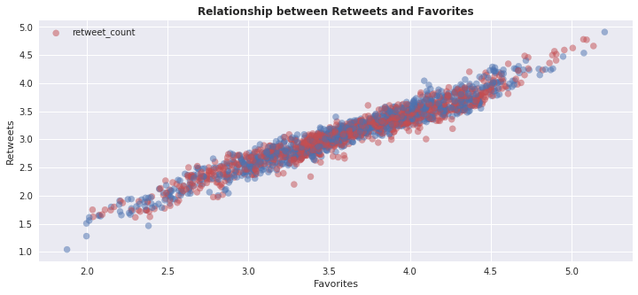

```
Retweets and Favorites have a positive relationship.
```

```python
#Plot relationship between Retweets and Favorites

fig,ax = plt.subplots(figsize =(12,5))
#x=  metrics_by_rating.log_fav
#y= metrics_by_rating.log_ret
x = np.log10(tweets['favorite_count'])
y = np.log10(tweets['retweet_count'])
color = 'RB'
# Plot
scatter = plt.scatter(x=x, y=y, color=color, alpha=0.5, s= 50)
plt.title('Relationship between Retweets and Favorites', weight = 'bold')
plt.xlabel('Favorites')
plt.ylabel('Retweets')
plt.legend()

ax.grid(True)
plt.savefig('rt_Vs_fav.png')
plt.show()

print('\033[91m\033[1m'"Retweets and Favorites have a positive relationship.")
```

#### Insight: What has the trend over time been for retweets and favorites?

Here, the trend over time for retweets and favorites is shown (15 November 2015 - 31 July 2017)

```python
# Group data from tweets and make timestamp as index
#  Omitted data from August 2017
metrics_by_time = tweets.groupby([pd.Grouper(freq = 'M', key = 'timestamp')]).agg({'favorite_count':["sum"],'retweet_count': ["sum"], 'rating': ["count"]}).reset_index()[:-1]
metrics_by_time['log_fav'] = np.log10(metrics_by_time['favorite_count'])
metrics_by_time['log_ret'] = np.log10(metrics_by_time['retweet_count'])
metrics_by_time['date'] = metrics_by_time['timestamp'].map(lambda x: 100*x.year + x.month)
metrics_by_time.columns = metrics_by_time.columns.droplevel(1)
metrics_by_time.columns.values[3] = "rating_count"  # rename
metrics_by_time.set_index('timestamp',inplace=True) # set date as index

metrics_by_time.head(1)
```

| timestamp | favorite_count | retweet_count | rating_count | log_fav | log_ret | date |
| --- | --- | --- | --- | --- | --- | --- |
| 2015-11-30 | 359395 | 149881 | 295 | 5.555572 | 5.175747 | 201511 |

[figure not shown]

```
Looks like people are more generous with retweets and favorites at year end. Most likely due to the festive period when most people feel warm and merry.
The most apparent downward trend for both Favorite and Retweet is in April 2016.
They peaked in June 2016 and dropped a month after. Otherwise, from then onwards they continue to grow.
```

```python
#Plot trend over time for retweets and favorites
fig, ax = plt.subplots(figsize=(14,5))

metrics_by_time.plot(y = 'log_ret', ax=ax, label = 'Retweet')
metrics_by_time.plot(y = 'log_fav', ax=ax, label = 'Favorite', color='m')

plt.title("Trends for Retweets and Favorites Over Time\n '15 Nov 2015 - 31 Jul 2017'", weight='bold')
plt.xlabel('Time', weight='bold')
plt.ylabel('Retweets and Favorites (in log scale)', weight='bold')
plt.legend(['Favorite', 'Retweet'], loc=9)
plt.tight_layout()
plt.savefig('rt_fav_trend.png')
plt.show()
print('\033[91m\033[1m'"Looks like people are more generous with retweets and favorites at year end. Most likely due to the festive period when most people feel warm and merry.")
print("The most apparent downward trend for both Favorite and Retweet is in April 2016.")
print("They peaked in June 2016 and dropped a month after. Otherwise, from then onwards they continue to grow.")
```

#### Insight: Who made it to the top 5 favorites

This insight shows the dogs that make the top 5 favorite tweets

```python
# Get the top 5 highest favorites
top5_fav_breed = tweets.iloc[heapq.nlargest(5, tweets.index, key=lambda x: tweets['favorite_count'].iloc[x])]
top5_fav_breed = top5_fav_breed.reset_index(drop=True)
top5_fav_breed.head(1)
```

|  | tweet_id | timestamp | source | text | rating | name | date | day | dog_stage | retweet_count | favorite_count | jpg_url |
| --- | --- | --- | --- | --- | --- | --- | --- | --- | --- | --- | --- | --- |
| 0 | 744234799360020481 | 2016-06-18 18:26:18 | Twitter for iPhone | Here's a doggo realizing you can stand in a pool. 13/10 enlightened af (vid by Tina Conrad) | 13.0 | dog doe | 06-18-2016 | 5 | doggo | 80853 | 161229 | https://pbs.twimg.com/ext_tw_video_thumb/744234667679821824/pu/img/1GaWmtJtdqzZV7jy.jpg |

```python
#Store URLs for top 5 favorites in a list
top5_fav_url = []

i = 0
for jpg_url in top5_fav_breed.jpg_url:
    image = top5_fav_breed.jpg_url
    image_url = image.values[i]
    i = i+1
    top5_fav_url.append(image_url)

top5_fav_url
```

```
['https://pbs.twimg.com/ext_tw_video_thumb/744234667679821824/pu/img/1GaWmtJtdqzZV7jy.jpg',
 'https://pbs.twimg.com/media/C2tugXLXgAArJO4.jpg',
 'https://pbs.twimg.com/ext_tw_video_thumb/807106774843039744/pu/img/8XZg1xW35Xp2J6JW.jpg',
 'https://pbs.twimg.com/media/DAZAUfBXcAAG_Nn.jpg',
 'https://pbs.twimg.com/ext_tw_video_thumb/739238016737267712/pu/img/-tLpyiuIzD5zR1et.jpg']
```

```python
# Verify if image(jpg) files have been created

# Generate list of jpg file names from folder
jpg_exists = []
with os.scandir('top5fav/') as top5fav:
    for jpg in top5fav:
        #print(entry.name)
        file_name,extension = splitext(jpg)
        #print(extension)
        if extension == ".jpg":
            jpg_exists.append(jpg.name)

# Generate list of jpg file names from URL list
top5_fav_jpg = []
for url in top5_fav_url:
    filename_verify = url.split('/')[-1]
    top5_fav_jpg.append(filename_verify)

if set(top5_fav_jpg) == set(jpg_exists):
    jpg_created = 1
    print(jpg_created)
```

```
1
```

```python
# Store downloaded images based on url list in folder : top5fav

if jpg_created != 1: # Check if image files are already in folder, if yes omit next step
    for url in top5_fav_url:
        filename = url.split('/')[-1]
        #Foldername = url.split('/')[-1].split('.')[0]
        Foldername = 'top5fav'
        if not os.path.exists(Foldername):
            os.mkdir(Foldername)
        cwd = os.getcwd()
        Filepath =  cwd.replace("\\", "/")
        response = requests.get(url, stream=True)
        with open(filename, 'wb') as out_file:
            shutil.copyfileobj(response.raw, out_file)
        del response
        shutil.move(Filepath + "/" + filename, Filepath + "/" + Foldername)
```

```
In no particular order, here are the Top 5 Favorite Dogs:
C2tugXLXgAArJO4.jpg
```

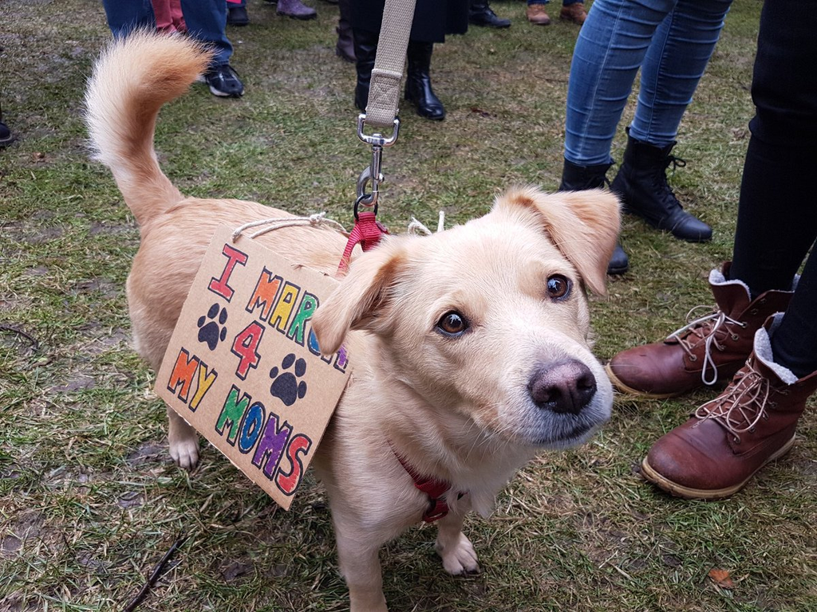

```
-tLpyiuIzD5zR1et.jpg
```

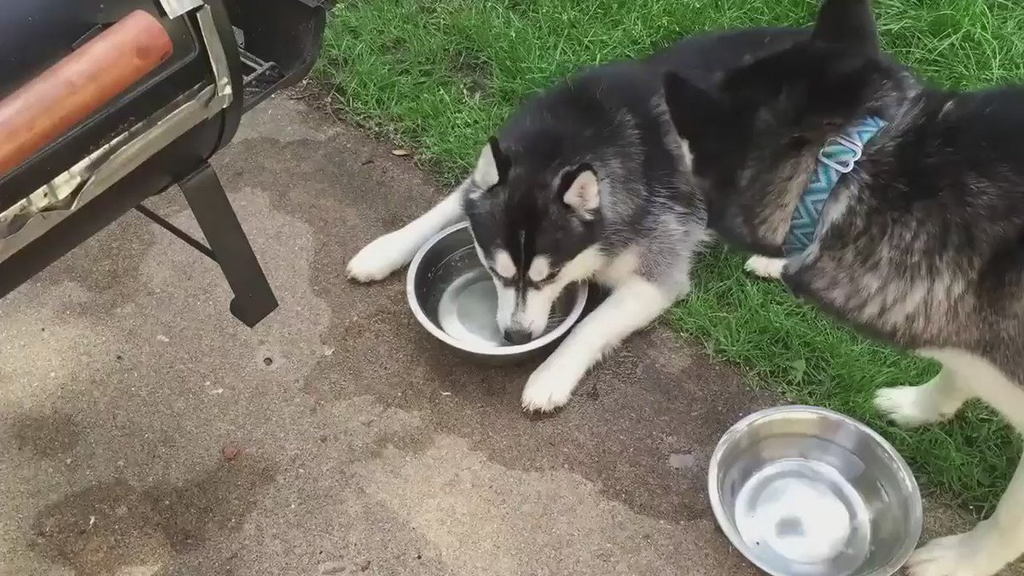

```
1GaWmtJtdqzZV7jy.jpg
```

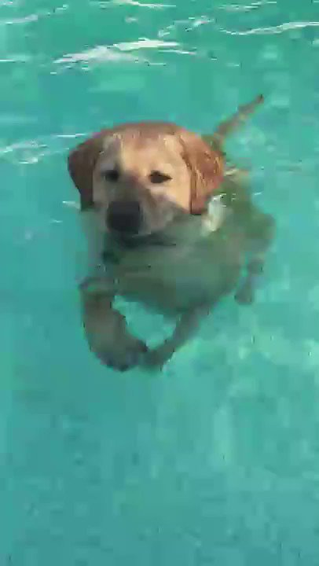

```
8XZg1xW35Xp2J6JW.jpg
```

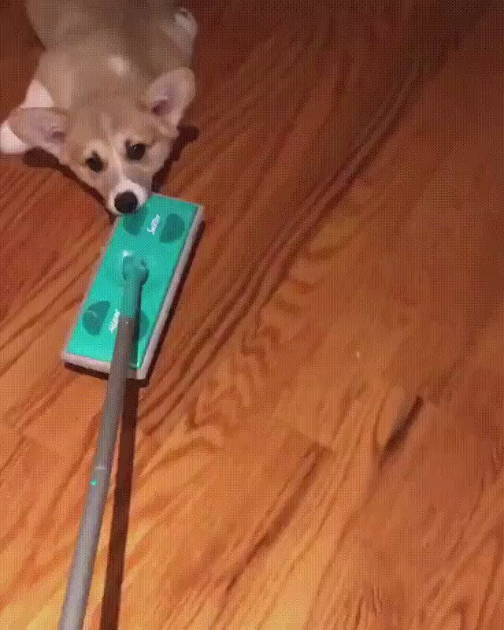

```
DAZAUfBXcAAG_Nn.jpg
```

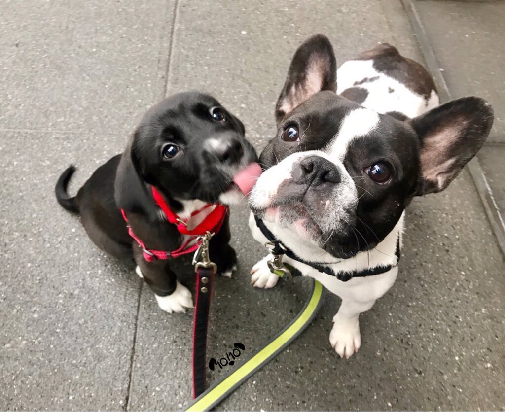

```python
# Display the top 5 favorite dogs
folder = "./top5fav"
onlyfiles = [f for f in os.listdir(folder) if os.path.isfile(os.path.join(folder, f))]

print('\033[91m\033[1m'"In no particular order, here are the Top {0} Favorite Dogs: ".format(len(onlyfiles)))

for i in range(0, 5):
    print(onlyfiles[i])
    display(_Imgdis(filename=folder + "/" + onlyfiles[i], width=200, height=100))
```

#### Insight: Who made it to the top 5 retweets

This insight shows dogs that make the top 5 retweets list

```python
# Get the top 5 highest retweets
top5_rt = tweets.iloc[heapq.nlargest(5, tweets.index, key=lambda x: tweets['retweet_count'].iloc[x])]
top5_rt = top5_rt.reset_index(drop=True)
top5_rt.head(1)
```

|  | tweet_id | timestamp | source | text | rating | name | date | day | dog_stage | retweet_count | favorite_count | jpg_url |
| --- | --- | --- | --- | --- | --- | --- | --- | --- | --- | --- | --- | --- |
| 0 | 744234799360020481 | 2016-06-18 18:26:18 | Twitter for iPhone | Here's a doggo realizing you can stand in a pool. 13/10 enlightened af (vid by Tina Conrad) | 13.0 | dog doe | 06-18-2016 | 5 | doggo | 80853 | 161229 | https://pbs.twimg.com/ext_tw_video_thumb/744234667679821824/pu/img/1GaWmtJtdqzZV7jy.jpg |

```python
#Store URLs for top 5 retweets in a list
top5_rt_url = []

i = 0
for jpg_url in top5_rt.jpg_url:
    image = top5_rt.jpg_url
    image_url = image.values[i]
    i = i+1
    top5_rt_url.append(image_url)

#top5_rt_url
```

```python
# Verify if image(jpg) files have been created

# Generate list of jpg file names from folder
jpg_rt_exists = []
with os.scandir('top5rt/') as top5rt:
    for jpg in top5rt:
        #print(entry.name)
        file_name,extension = splitext(jpg)
        #print(extension)
        if extension == ".jpg":
            jpg_rt_exists.append(jpg.name)

# Generate list of jpg file names from URL list
top5_rt_jpg = []
for url in top5_rt_url:
    filename_verify = url.split('/')[-1]
    top5_rt_jpg.append(filename_verify)

if set(top5_rt_jpg) == set(jpg_rt_exists):
    jpg_rt_created = 1
    print(jpg_rt_created)
```

```
1
```

```python
# Store downloaded images based on url list in folder : top5rt
if jpg_rt_created != 1: # Check if image files are already in folder, if yes omit next step
    for url in top5_rt_url:
        filename = url.split('/')[-1]
        #Foldername = url.split('/')[-1].split('.')[0]
        Foldername = 'top5rt'
        if not os.path.exists(Foldername):
            os.mkdir(Foldername)
        cwd = os.getcwd()
        Filepath =  cwd.replace("\\", "/")
        response = requests.get(url, stream=True)
        with open(filename, 'wb') as out_file:
            shutil.copyfileobj(response.raw, out_file)
        del response
        shutil.move(Filepath + "/" + filename, Filepath + "/" + Foldername)
```

```
In no particular order, here are the Top 5 Retweeted Dogs:
C2tugXLXgAArJO4.jpg
```

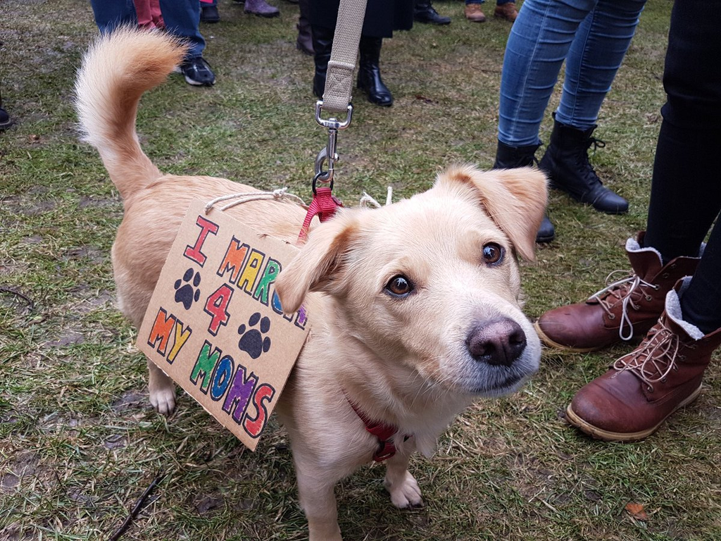

```
-tLpyiuIzD5zR1et.jpg
```

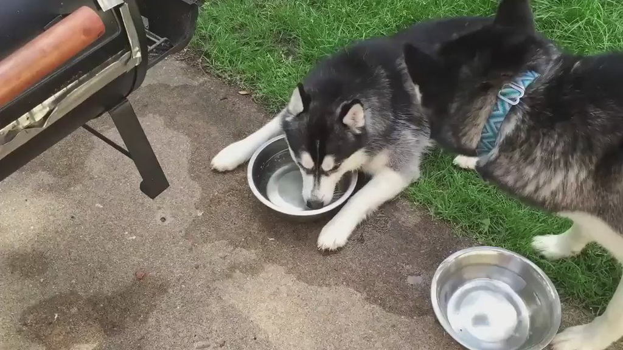

```
1GaWmtJtdqzZV7jy.jpg
```

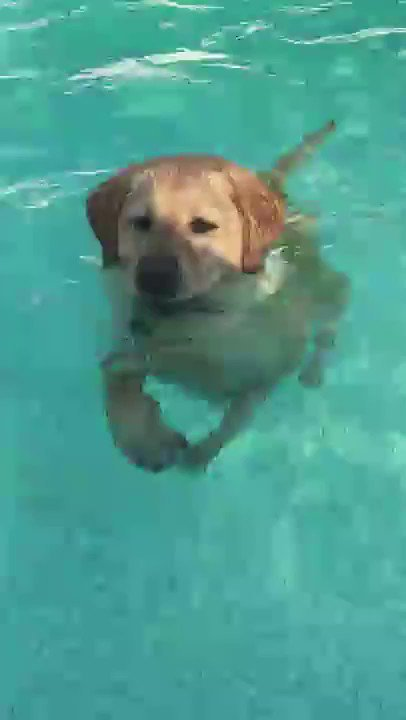

```
cX7XI1TnUsseGET5.jpg
```

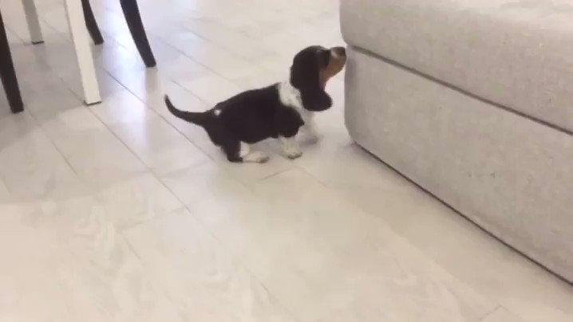

```
8XZg1xW35Xp2J6JW.jpg
```

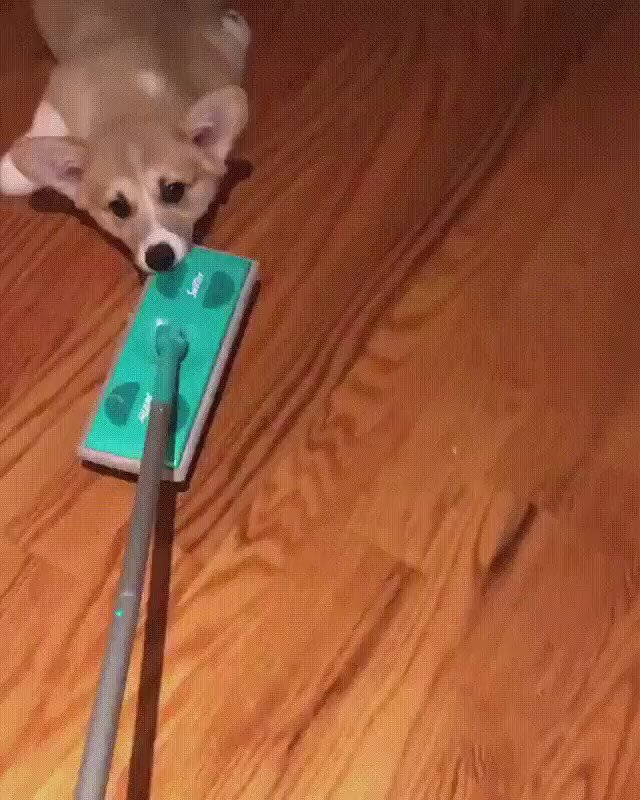

```python
# Display the top 5 retweeted dogs
folder = "./top5rt"
onlyfiles = [f for f in os.listdir(folder) if os.path.isfile(os.path.join(folder, f))]
print('\033[91m\033[1m'"In no particular order, here are the Top {0} Retweeted Dogs: ".format(len(onlyfiles)))

for i in range(0, 5):
    print(onlyfiles[i])
    jpg_name = onlyfiles[i]
    #if top5_rt[top5_rt['jpg_url'].str.contains(jpg_name)]:
     #   print(top5_rt.text)
    display(_Imgdis(filename=folder + "/" + onlyfiles[i], width=200, height=100))
```

```python
#Move all image files generated via savefig into folder called visualizations

dst = 'visualizations/' #declare destination folder
src = os.getcwd()       #declare source folder

with os.scandir(os.getcwd()) as home_dir:
    for png in home_dir:
        file_name,extension = splitext(png)
        if extension == ".png":
            filename = png.name
            shutil.move(os.path.join(src, filename), os.path.join(dst, filename))
```

## Bibliography

Go back to list of contents

1. https://knowledge.udacity.com/questions/46558
2. https://knowledge.udacity.com/questions/21718
3. https://dzone.com/articles/pandas-find-rows-where-columnfield-is-null
4. https://stackoverflow.com/questions/12934997/how-to-detect-lowercase-letters-in-python/37037484
5. https://stackoverflow.com/questions/25351968/how-to-display-full-non-truncated-dataframe-information-in-html-when-convertin
6. https://pandas.pydata.org/pandas-docs/stable/reference/api/pandas.Series.str.title.html#pandas.Series.str.title
7. https://rubular.com/r/sZ2raKn98v
8. https://regexone.com/
9. https://stackoverflow.com/questions/15535205/what-does-1-mean-do-in-python
10. https://stackoverflow.com/questions/38812372/round-approximate-a-float-number-to-3-decimal-place-in-python-pandas-dataframe
11. https://stackoverflow.com/questions/31511997/pandas-dataframe-replace-all-values-in-a-column-based-on-condition
12. https://stackoverflow.com/questions/47280777/adding-new-column-to-pandas-dataframe-to-indicate-duplicates-in-specific-columns
13. https://stackoverflow.com/questions/50449088/check-if-value-from-one-dataframe-exists-in-another-dataframe
14. https://pandas.pydata.org/pandas-docs/stable/user_guide/missing_data.html
15. https://stackoverflow.com/questions/43956335/convert-float64-column-to-int64-in-pandas
16. https://medium.com/@wangyuw/data-reshaping-with-pandas-explained-80b2f51f88d2
17. https://stackoverflow.com/questions/16630969/ipython-notebook-anchor-link-to-refer-a-cell-directly-from-outside
18. https://stackoverflow.com/questions/19350082/how-to-get-top-n-value-in-python
19. https://www.reddit.com/r/learnpython/comments/axnwpx/python_download_images_into_specific_directory/
20. https://www.codecademy.com/articles/seaborn-design-ii
21. https://www.tutorialspoint.com/seaborn/seaborn_facet_grid
22. https://stackoverflow.com/questions/39714724/pandas-plot-x-axis-tick-frequency-how-can-i-show-more-ticks/39907390#39907390
23. https://stackoverflow.com/questions/37896386/how-to-get-file-extension-correctly

Source for dog silhouette: http://www.clker.com/cliparts/0/f/e/b/1433163706283394587dog%20silhoutte%20correct%20direction-md.png

```python
from subprocess import call
call(['python', '-m', 'nbconvert', 'wrangle_act.ipynb'])
```

```
0
```